# 如何用AI生成带透明通道的图片

# 如何用AI生成带透明通道的图片？免抠图直出。

> 全文约 **1476** 字，阅读约 **4** 分钟

以前常用的制作透明图的方法，都是Ai生成带颜色底的图片之后再抠图。现在这个繁琐的步骤可以省掉了。

gpt-image-2 已经灰度支持在API中直接请求透明背景，返回自带Alpha通道的 PNG 图片。生成出来就能直接换底色，对于边缘不复杂的素材，基本可以告别后续抠图。

下面介绍两种生成透明图的方法，第二种适合所有新手操作：

### 01 直接生图

**API调用直接生图｜gpt-image-2**

**生成透明图的核心代码**

市面上能做透明图的工具不少，但大多是“先生成完整图片，再调用算法去背景”（比如 Ideogram、Recraft 或 Adobe 的相关流程）。

**gpt-image-2 直接一步到位**，在生图请求中传入核心参数即可：

`"background": "transparent"`

⚠️

**注意：**

该功能目前处于 Preview 阶段，仅支持输出 PNG 或 WebP 格式（JPEG 本身不支持透明通道）。在当前主流的生图模型中，

`gpt-image-2`

是目前唯一实测支持该原生参数的模型。

### 🔍 实测验证：同主体（植物精华液）三种写法对比

**• 图 1（只在 Prompt 写“背景透明”）：**

模型完全理解错了，直接画出了“假透明”的黑白棋盘格，文件仍是普通 RGB 格式，棋盘格被当成了画面的一部分。

**• 图 2（只传 background: "transparent" 参数）：**

返回了真正的 RGBA 透明文件，但因为 Prompt 没有排除场景，模型把瓶底的地面反射和倒影也保留了下来。

**• 图 3（参数 + Prompt 协同指定）：**

参数开启透明，同时 Prompt 明确要求“不要地面、倒影和投影”，最终拿到了边缘非常干净、主体之外完全透明的母图。

[figure not shown]

### 📊 透明 PNG 文件信息与 Alpha 通道验证

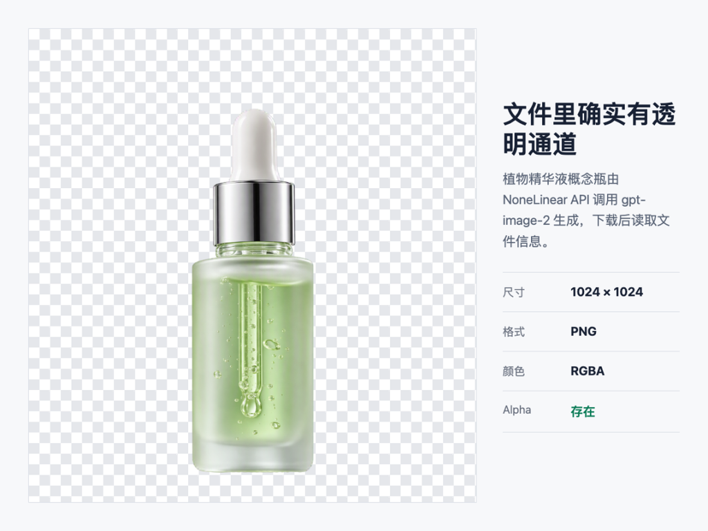

[figure not shown]

#### 📌 关键配置划重点：

- 请求体必须带 "background": "transparent"；
- "output_format" 必须指定为 "png"（或 "webp"）；
- Prompt 建议配合负向描述，明确排除“地面、倒影、投影、场景”，避免留下多余的阴影碎片。

💰 **注：**在非线智能（NoneLinear）通过 image2 生成一张图片**价格低至 3 分钱**，支持高并发和批量操作

### 💻 已调通 cURL 代码（已注册 nonelinear.com 用户直接复用）

换上您的 API Key，调整 Prompt 即可直接生成透明 PNG：

```bash
curl -sS --max-time 300 \
https://api.nonelinear.com/v1/images/generations \
-H "Authorization: Bearer YOUR_API_KEY" \
-H "Content-Type: application/json" \
-d '{
"model": "gpt-image-2",
"prompt": "一瓶高端植物精华液的电商商品图，磨砂玻璃瓶身，浅绿色精华液，银色滴管盖，瓶身没有文字和品牌标识，正面略微侧转，产品完整，专业棚拍质感，材质细节清晰，透明背景，不要白色或纯色背景，不要人物、包装、场景、地面、底座、投影和额外物体",
"response_format": "url",
"output_format": "png",
"background": "transparent",
"size": "1024x1024",
"quality": "high",
"n": 1
}'
```

### 02 工具调用生图

**开发/办公工具｜生图Skill调用**

**在Workbuddy /Claude Code生图**

如果你不想写代码调用 API，推荐使用 **非线智能生图Skill**。只需 3 步即可在对话框中用自然语言批量生成透明小动物贴纸！

**步骤一：发指令让 AI 安装 Skill**

在 WorkBuddy 对话框中，确保底部已勾选**「允许完全访问」**，直接发送如下指令，AI 会自动从 GitHub 下载 Release 包并完成本地安装和安全审查：

查看这个项目 https://github.com/Fitnessnlp/nonelinear-skills/releases，并且下载安装成为Skill，告诉我需要补充什么资料给你

[figure not shown]

**步骤二：获取 Nonelinear API Key 并配置**

① WorkBuddy 安装完成并提示补充资料：

[figure not shown]

② 在 Nonelinear 平台复制 API Key 发送给 AI：

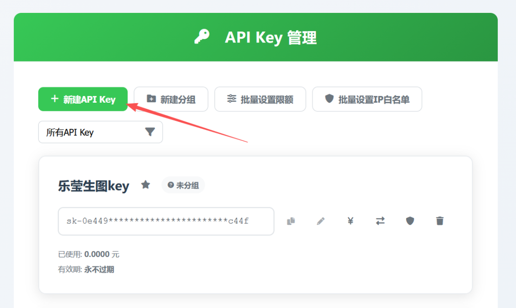

**步骤三：重启客户端，勾选技能开始透明生图**

**重启 WorkBuddy** 使环境变量生效。在输入框左侧技能面板中勾选 **「nonelinear-image」**，然后发送生图指令：

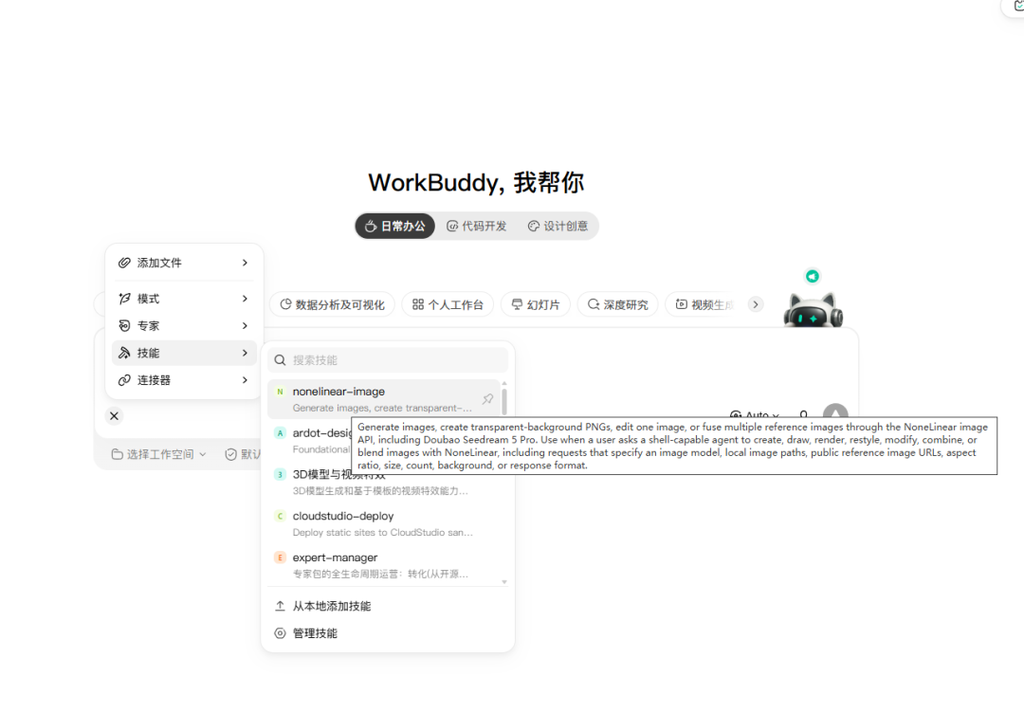

**🎯 生图 Prompt 示例：**

用Image2生成带Alpha透明图1张。内容为：20个卡通小动物贴纸。

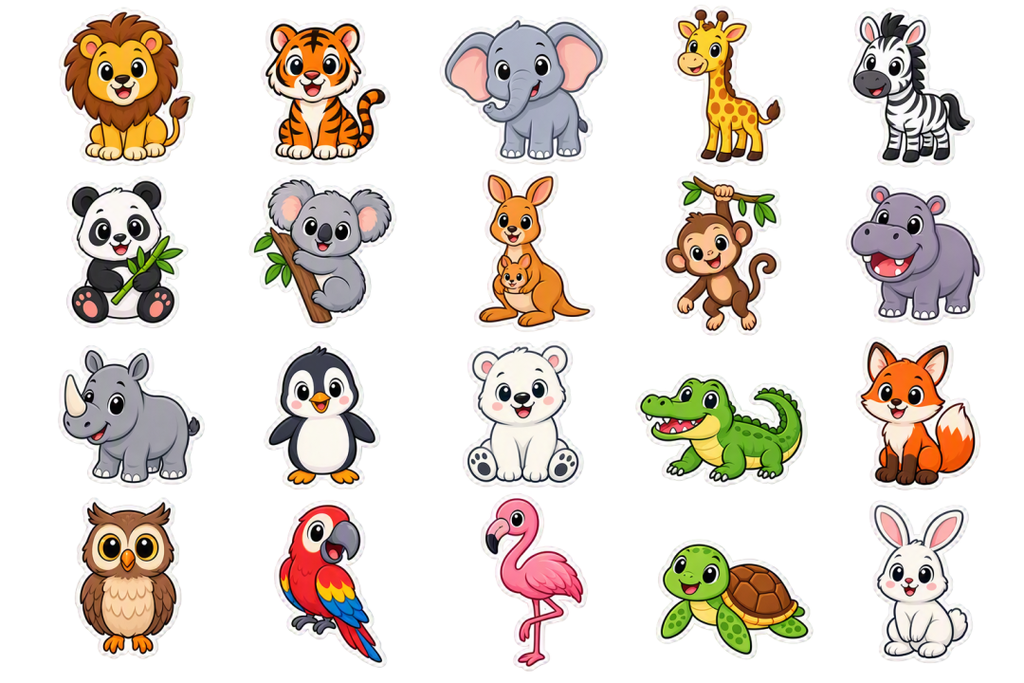

**快来试试吧！**

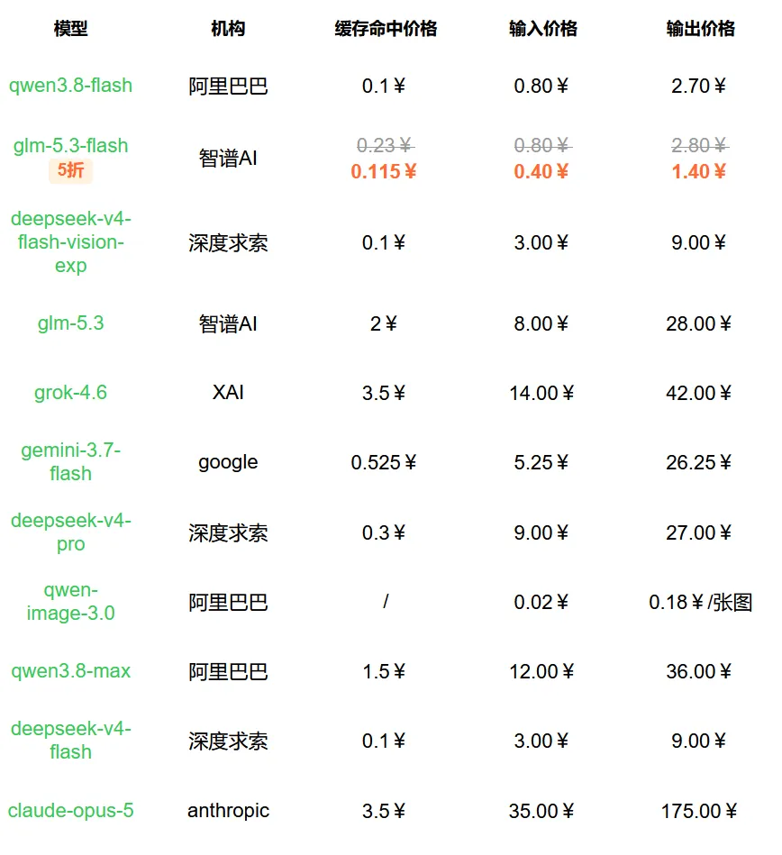

**非线智能**

**Nonelinear.com**

9月20日前新用户

**充 20 送 2**

**（约80~**

**500张图）**

充 值

** 5000 送 1000**

全部模型，折扣共享

📎 **原始 Word 文件**：02-AI生成透明通道图片.docx